# Classifying Wines by Data Mining from Physicochemical Properties

Std Nr: 160223367

2/05/2019

# 1 Analysis

## 1.1 Intrdocution

We attempt here to build a classifier, using methods of machine learning (ML), which based on 12 physical and chemical measurements of a wine predict if is good or not as good (poor) determined by experts. The dataset to our disposal consists of 5000 observation. The explanatory variables include measurements of, e.g. alcohol, chloride, citric acid concentrations, or of the wine color (white, red). There is also a binary variable quality, determined by an expert assessment, which we will be trying to predict for new observations using the ML model.

In the original publication (Cortez et al. 2009) the white and red wine datasets were modeled separately since, “red and white tastes are quite different.” In the original dataset, the quality was an ordinal variable, with ten levels. Therefore, to model, the response regression models were used, and the authors reported the mean absolute deviation as a measure of model performance. For our study, the quality was collapsed into two categories $quality \le 5$ and $quality > 5$ which we renamed here in “poor” and “good.” Hence, we represented the quality as a categorical variable (factor) and use binary classification. To asses the performance of the binary classifiers, we will use a measure suitable for binary classification, namely the ROC curves, as well as well as Cohen’s Kappa and Sensitivity and Specificity measures. We also do not split the dataset into white and red wines but build on model for both types of wines and use the wine color as an additional explanatory variable.

Most of the analysis is performed using the `caret` package (Kuhn 2008), which provides a unified interface to many ML algorithms. It also facilitates data preprocessing, and model comparison. A further feature of the `caret` package we utilized is that it facilitates tuning of model hyperparameters.

## 1.2 The Data

Table 1.1 shows that the dataset includes three times more white than red wines. In the original study, the dataset was split into the white and red wines, and separate models were trained for these two types of wine. We run a few preliminary tests, and observed that models build on the subset of data do not perform significantly better than on the entire dataset (results not shown).

We also see that approximately two-thirds of the ratings were positive. That means we can obtain a prediction accuracy of approximately $60\%$ by just always predicting that the wine is good. Because of this, we decided to use the Cohens Kappa measure, which normalizes for the imbalance in the classes, to asses the performance of the ML models.

Table 1.1: Summary of the dataset

| Wine | rating_up_to_5 | rating_above_5 | nr | percentage |
| --- | --- | --- | --- | --- |
| all | 36 | 64 | 5000 | 100 |
| white | 33 | 67 | 3771 | 75 |
| red | 45 | 55 | 1229 | 25 |

## 1.3 Data preprocessing

Transforming and scaling the variables towards normality can improve the performance of ML models. To this task, we used the `preProcess` method of the `caret` package and transformed the data using the BoxCox transformation. The supplementary Table 3.1 shows the five-number summaries of all variables in the original dataset.

Furthermore, we split the data into a training ($80\%$) and test ($20\%$) dataset. The training dataset will be used to train the models as well as to tune the hyperparameters. We used the test dataset to compare the tuned ML models among each other and select the best ML model.

## 1.4 Hyperparameter tuning

The number of hyperparameters for the Machine learning algorithms tested ranges between 0 (e.g. LDA, glm) to up to 7 (mlpKerasDropoutCost) or 8 (xgbDART). Therefore, for some of the models, the training had to be performed at several hundred design points which can be time-consuming. Figure 1.1 shows the results of evaluating the model `xgbLinear` at $125$ design points sampling the parameters $\lambda$, $\alpha$, at 5 locations.

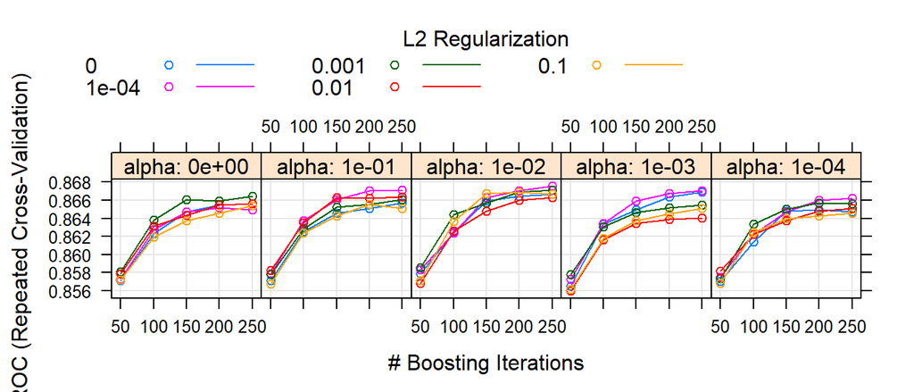

Figure 1.1: Hyperparamter scan for the xgbLinear model. Y axis AUC - ROC.

The number of hyperparameters for the Machine learning algorithms tested ranges between 0 (e.g. lda, glm) to up to 7 (mlpKerasDropoutCost) or 8 (xgbDART) (see Table 3.2). Therefore, for some of models the training had to be performed at several hundred design points which obviously takes a lot of time.

## 1.5 Comparing models

After the parameter tuning, using the ten-fold cross-validation, we will be comparing the models using our test dataset ($20%$ of the data). Using the test set, we made predictions from all trained ML models, determined the confusion matrix, and computed various performance measures using the function `confusionMatrix,` which we will use to compare the models.

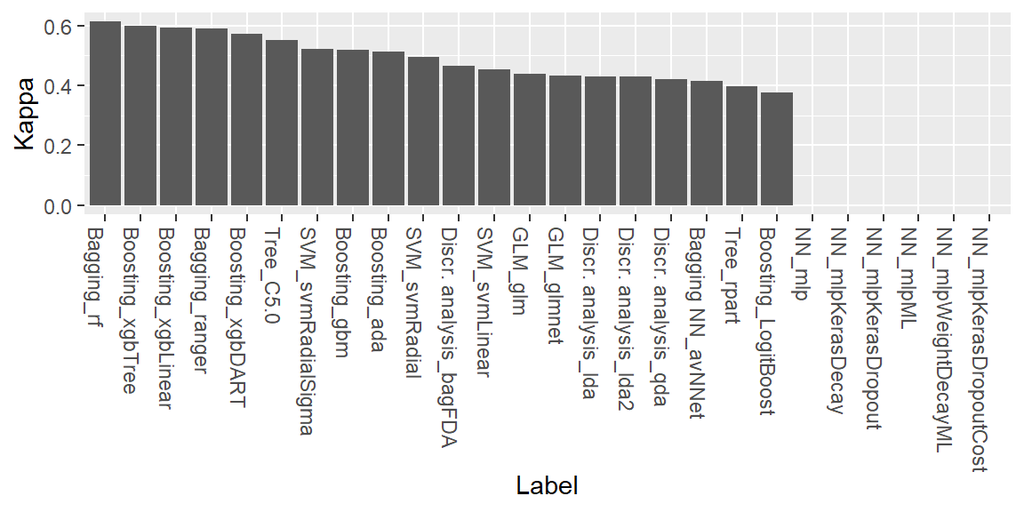

Figure 1.2: Cohens Kappa values for the algorithms tested using the caret API

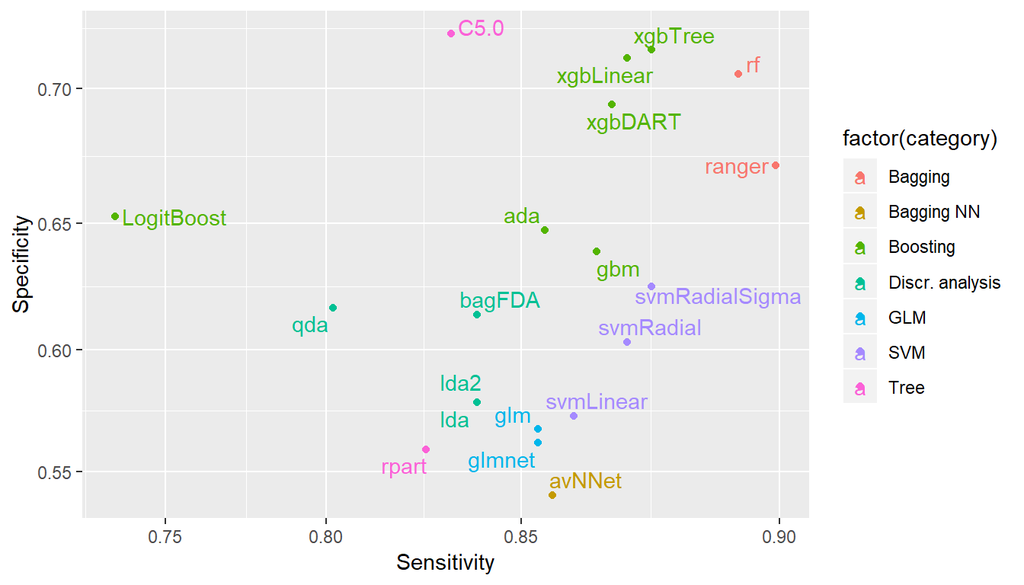

We also compare the prediction speed of the generated models. In practice, ML models are deployed in settings where compute power might be limited while prediction speed is critical (Cars, Security). How much time it takes to learn the model, given today’s computer capabilities, is secondary. Figure 1.4 shows the prediction time on the x-axis and kappa on the y-axis. We observed that simple models, e.g. `lda`, `glm` predict fast, while random forests e.g. `ranger`, `rf`, are rather slow. Luckily some of the best models xgbTree, xgbLinear, and xgbDART are well implemented and make very fast predictions fast. Hence, for this reason we prefer them over the random forrest implementations.

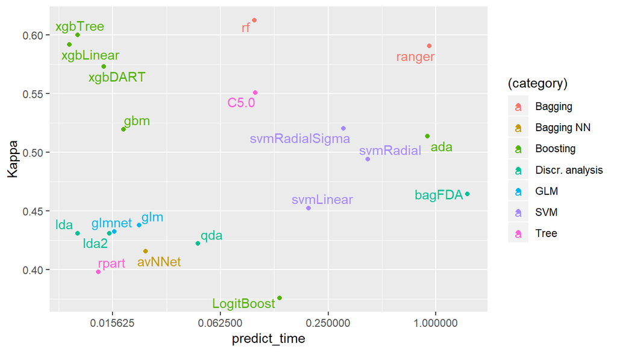

Figure 1.4: Kappa vs prediction time for 1000 tests cases in seconds

## 1.7 Deployment

The model consists of the data transformation applied to the inputs as well as the ML model. We created the function `should_I_drink_these_wines` which contains the transformation and ML model all this data and stored in the file `should_I_drink_these_wines.rds.` In order to make predictions with new data what is needed is to deserialize it and pass a dataframe with the explanatory variables (see code snippet below).

```r
library(tidyverse)
library(caret)
library(xgboost)
rm(list=ls())
should_I_drink_these_wines <- readRDS(file = "should_I_drink_these_wines.rds")

data_RW <- read_csv("winetrain.csv") %>% dplyr::select(-X1)

test_sample_X <- sample_n(data_RW,10)
test_sample <- dplyr::select(test_sample_X, -quality)

confusionMatrix(should_I_drink_these_wines(test_sample), as.factor(test_sample_X$quality))
```

# 2 Recreating the analysis

Run the following R files from the `R` folder in Sequence:

- `dataSetup.R`
- `testingAllModelsAndSaving.R` (very long running script)
- `analysingResults.R`
- `deployment.R`

The file `modelFunctions.R` contains the `caras` code.

# 3 Supplement

Table 3.1: Data summary.

| type | variable | complete | ordered | mean | sd | p0 | p25 | p50 | p75 | p100 |
| --- | --- | --- | --- | --- | --- | --- | --- | --- | --- | --- |
| factor | colour | 5000 | FALSE | NA | NA | NA | NA | NA | NA | NA |
| factor | quality | 5000 | FALSE | NA | NA | NA | NA | NA | NA | NA |
| numeric | alcohol | 5000 | NA | 10.5 | 1.2 | 8 | 9.5 | 10.3 | 11.3 | 14.9 |
| numeric | chlorides | 5000 | NA | 0.056 | 0.035 | 0.009 | 0.038 | 0.047 | 0.065 | 0.61 |
| numeric | citric.acid | 5000 | NA | 0.32 | 0.15 | 0 | 0.25 | 0.31 | 0.39 | 1.66 |
| numeric | density | 5000 | NA | 0.99 | 0.003 | 0.99 | 0.99 | 0.99 | 1 | 1.04 |
| numeric | fixed.acidity | 5000 | NA | 7.21 | 1.3 | 3.8 | 6.4 | 7 | 7.7 | 15.9 |
| numeric | free.sulfur.dioxide | 5000 | NA | 30.42 | 17.79 | 1 | 17 | 29 | 41 | 289 |
| numeric | pH | 5000 | NA | 3.22 | 0.16 | 2.72 | 3.11 | 3.21 | 3.32 | 4.01 |
| numeric | residual.sugar | 5000 | NA | 5.37 | 4.72 | 0.6 | 1.8 | 3 | 8 | 65.8 |
| numeric | sulphates | 5000 | NA | 0.53 | 0.15 | 0.22 | 0.43 | 0.51 | 0.6 | 2 |
| numeric | total.sulfur.dioxide | 5000 | NA | 115.69 | 56.64 | 6 | 77 | 118 | 156 | 440 |
| numeric | volatile.acidity | 5000 | NA | 0.34 | 0.17 | 0.08 | 0.23 | 0.29 | 0.4 | 1.58 |

Table 3.2: ML algorithm summaries. pred time - prediction time in s for 1000 samples

| name | description | category | hyperparms | pred_time | Kappa |
| --- | --- | --- | --- | --- | --- |
| ada | Boosted Classification Trees | Boosting | 2 | 0.90 | 0.51 |
| avNNet | Model Averaged Neural Network | Bagging NN | 2 | 0.02 | 0.42 |
| gbm | Stochastic Gradient Boosting | Boosting | 3 | 0.02 | 0.52 |
| glm | Generalized Linear Model | GLM | 0 | 0.02 | 0.44 |
| glmnet | Generalized Linear Model - Lasso | GLM | 1 | 0.02 | 0.43 |
| lda | Linear Discr. Analysis | Discr. analysis | 0 | 0.01 | 0.43 |
| lda2 | Linear Discr. Analysis | Discr. analysis | 0 | 0.01 | 0.43 |
| LogitBoost | Boosted Logistic Regression | Boosting | 0 | 0.13 | 0.38 |
| mlp | Multi-Layer Perceptron | NN | 0 | 0.05 | 0.00 |
| mlpKerasDecay | Multil. Perc. Net. with Weight Decay | NN | 6 | 1.83 | 0.00 |
| mlpKerasDropout | Multil. Perc. Network with Dropout | NN | 6 | 1.80 | 0.00 |
| mlpKerasDropoutCost | Multil. Perc. Network with Dropout | NN | 7 | 4.75 | 0.00 |
| mlpML | Multil. Perc. Network | NN | 2 | 0.03 | 0.00 |
| mlpWeightDecayML | Multil. Perc. Network | NN | 3 | 0.04 | 0.00 |
| qda | Quadratic Discr. Analysis | Discr. analysis | 0 | 0.05 | 0.42 |
| rf | Random Forest | Bagging | 0 | 0.10 | 0.61 |
| ranger | Random Forest | Bagging | 2 | 0.92 | 0.59 |
| rpart | CART | Tree | 0 | 0.01 | 0.40 |
| svmLinear | SVM | SVM | 0 | 0.19 | 0.45 |
| svmRadial | SVM | SVM | 1 | 0.42 | 0.49 |
| svmRadialSigma | SVM | SVM | 1 | 0.30 | 0.52 |
| xgbDART | Boosted Trees | Boosting | 8 | 0.01 | 0.57 |
| xgbLinear | Boosted Trees | Boosting | 3 | 0.01 | 0.59 |
| xgbTree | Boosted Trees | Boosting | 6 | 0.01 | 0.60 |
| bagFDA | Bagged Flexible Discr. Analysis | Discr. analysis | 1 | 1.50 | 0.46 |
| C5.0 | Tree | Tree | 2 | 0.10 | 0.55 |